# Exercise 1: Basic concepts on random variables and probability distributions

### Part II: Probability distributions

#### Question II.1

The number of rainy days in July and August at a meteorological station is given in the table below.

| Year | 1 | 2 | 3 | 4 | 5 | 6 | 7 | 8 | 9 | 10 |
| --- | --- | --- | --- | --- | --- | --- | --- | --- | --- | --- |
| July | 10 | 15 | 17 | 8 | 9 | 19 | 17 | 14 | 20 | 4 |
| August | 4 | 9 | 8 | 3 | 0 | 10 | 12 | 2 | 8 | 6 |

##### a) Use the Hypergeometric, Binomial and Poisson distributions to calculate

1) What is the probability of 10 rainy days in each of the months of July and August?

2) What is the probability of 20 rainy days in the 2 month period?

*Note: if you wish to use factorial function then you have to import the module 'math' by the command 'import math' then write: math.factorial(x)*

- **Hint: Hypergeometric distribution:**

  ```
  from scipy.stats import hypergeom
    hypergeom.pmf(x, N, n, k)
  ```

  where

  ```
    - k is the number of "successes" in the population
    - x is the number of "successes" in the sample
    - N is the size of the population
    - n is the number sampled
  ```

- **Hint: Binomial distribution**

  ```
  from scipy.stats import binom
    binom.pmf(x,n,p)
  ```

  where

  ```
    - p is the probability of success
    - n and x same as for the hypergeometric distribution
  ```

- **Hint: Poisson distribution**

  ```
  from scipy.stats import poisson
    poisson.pmf(x, λ)
  ```

  where $\lambda=p \cdot n$ (p and n are the same as for the binomial distribution)

```python
from scipy.stats import hypergeom

N=310
n=31
x10=10
x20=20
kj= 10+15+17+8+9+19+17+14+20+4
ka= 4+9+8+3+10+12+2+8+6
k20=ka+kj

#July
julyh10=hypergeom.pmf(x10, N, n, kj)

#August
augusth10=hypergeom.pmf(x10, N, n, ka)

print(julyh10,augusth10)

#two month period

twom=hypergeom.pmf(x20,N*2,n*2,k20)

print(twom)
```

```
0.07040685914299996 0.038462379596363276
0.11260953051396531
```

```python
from scipy.stats import binom

#July
pj= kj/310
julyb=binom.pmf(x10,n,pj)

#August
pa=ka/310
augustb=binom.pmf(x10,n,pa)

print(julyb,augustb)

#2 moth period
p2=k20/(2*310)
twomb=binom.pmf(x20,n*2,p2)

print(twomb)
```

```
0.07255332473998752 0.041889435487740774
0.10686514570194916
```

```python
from scipy.stats import poisson

#july
julyp=poisson.pmf(x10, pj*n)

#August
augustp=poisson.pmf(x10,pa*n)

print(julyp,augustp)

#2 omth period
twomp=poisson.pmf(x20,p2*(n*2))

print(twomp)
```

```
0.07991655742771149 0.04693837759360656
0.08827245664041036
```

##### b) Which assumptions in each method are likely violated by this problem?

```python
#That we assume that the weather for each day are independent of each other. If it rains today it is more likely that it wil rain tomorrow or that it rained yesterday
```

##### c) What is the probability that the sixth rainy day of August occurs on 30 August, assuming that rain occurrences are independent events?

**Hint: use one of the above distributions**

```python
# negative binomial

from scipy.stats import nbinom

x6=30
n6=30
k6=6
pa6=ka/310

augustb6=nbinom.pmf(n6,k6,pa6)

print(augustb6)
```

```
0.02571999685333051
```

#### Question II.2

A real estate developer tells a group of concerned citizens that a new housing project will be well prepared to tackle the problems associated with a 10-year flood and that there is nothing to worry about for the next 9 years. On the 10th year, when the flood will occur as he says, the local flood protection authority will have prepared everything. Compute the probability that the real estate developer is actually right and that the 10-year flood occurs on the 10th year for the first time.

```python
#
nf=10
kf=1
pf=1/10

flood=nbinom.pmf(nf,kf,pf)

print(flood)
```

```
0.03486784401000001
```

#### Question II.3

Assume that the annual maximum discharge at a river station is normally distributed with a mean of 75 m$^3$/s and a standard deviation of 10 m$^3$/s. What is the probability for any given year to have a maximum flow that is

a) less than 70 m$^3$/s?

b) larger than 95 m$^3$/s?

c) between 60 and 80 m$^3$/s?

d) What is the flow that is not exceeded with 90% probability?

e) What is the flow with 80% probability to be exceeded?

f) In which interval (centred on the mean) would 50% of the flows fall?

- **Hint**: you may use the following functions to find probability/quantile values of a normal distribution:
  - *scipy.stats.norm(mean, sd).cdf(quantile), where quantile is a discharge*
  - *scipy.stats.norm(mean, sd).ppf(percentile), where percentile is a proportion*

```python
from scipy.stats import norm

#less than 70 m3/s
less70= norm(75, 10).cdf(70)

print(less70)

#larger than 95 m3/s
large90=1-norm(75, 10).cdf(95)

print(large90)

#between 60 and 80 m3/s
large60=norm(75, 10).cdf(60)
less80=norm(75, 10).cdf(80)

between=less80-large60

print(between)
```

```
0.3085375387259869
0.02275013194817921
0.624655260005155
```

```python
#flow not exceeded with 90%
pro90=norm(75, 10).ppf(0.9)

print(pro90)


#flow 80% exceed

pro80=norm(75, 10).ppf(0.2)

print(pro80)

#50%
#since normal distribution is symetric around the mean we can find 25% on each side of mean

pro25=norm(75, 10).ppf(0.25)

#print(pro25)

pro75=norm(75,10).ppf(0.75)

#print(pro75)

print('the 50% interval is from',pro25,'to',pro75,'m3/s')
```

```
87.815515655446
66.58378766427086
the 50% interval is from 68.25510249803918 to 81.74489750196082 m3/s
```

#### Question II.4

a) Plot the individual terms of the Poisson distribution for $\lambda = 3$.

b) Approximate the Poisson by the normal and plot the normal approximations on the same graph.

c) (Optional) Do the same as in a) and b) but with $\lambda = 8$.

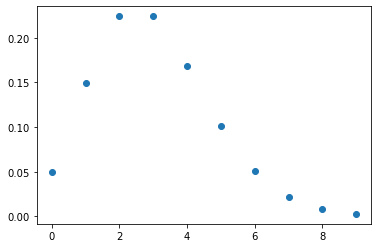

```python
#a)
lamb=3

xl = np.arange(0, 10, 1)
y = poisson.pmf(xl, lamb)

plt.scatter(xl, y)
plt.show()
```

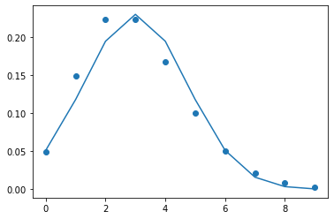

```python
#b)
lamb=3

normal=np.zeros(10)

xl = np.arange(0, 10, 1)
y = poisson.pmf(xl, lamb)

plt.scatter(xl, y)


for j in xl:
    z=(j-lamb)/np.sqrt(lamb)
    normal[j]=1/(np.sqrt(lamb)*np.sqrt(2*np.pi))*np.e**(-z**2/2)

plt.plot(xl,normal)

plt.show()
```

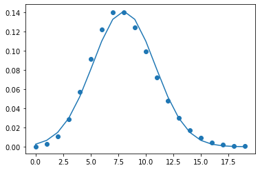

```python
#c)
lambd=8

normal=np.zeros(20)

xl = np.arange(0, 20, 1)
y = poisson.pmf(xl, lambd)

plt.scatter(xl, y)


for j in xl:
    z=(j-lambd)/np.sqrt(lambd)
    normal[j]=1/(np.sqrt(lambd)*np.sqrt(2*np.pi))*np.e**(-z**2/2)

plt.plot(xl,normal)

plt.show()
```